# Part I - Used Cars Data Analysis

## Introduction

> An automotive corporation from India named XYZ wants to enter the country's used-car industry by establishing a local business to compete with its rivals. Since these may differ greatly from the market for new automobiles, they want to understand the factors influencing car pricing and sales. In essence, the company seeks to understand: What factors are important in determining the cost of a used car? How well such factors reflect a car's price The consulting company has compiled a sizable dataset of various makes and models of used automobiles available on the market based on several market surveys. The dataset includes the different variables that will be helpful during the analysis phase, Sales ID, name, year, selling price, kilometers traveled, state or province, region, fuel type, owner, mileage, engine, maximum power, and number of seats sold. The data was obtained from kaggle.com.

## Preliminary Wrangling

```python
# import all packages and set plots to be embedded inline
import numpy as np
import pandas as pd
import matplotlib.pyplot as plt
import seaborn as sb

%matplotlib inline

# ignore warning messages
import warnings
warnings.filterwarnings('ignore')
```

```python
# Load data. Data was downloaded from Kaggle.com
used_cars_data = pd.read_csv('UserCarData.csv')

# Print the number of observations and features
print(used_cars_data.shape)

# show few lines of dataset
used_cars_data.head()
```

```
(7906, 18)
```

|  | Sales_ID | name | year | selling_price | km_driven | Region | State or Province | City | fuel | seller_type | transmission | owner | mileage | engine | max_power | torque | seats | sold |
| --- | --- | --- | --- | --- | --- | --- | --- | --- | --- | --- | --- | --- | --- | --- | --- | --- | --- | --- |
| 0 | 1 | Maruti | 2014 | 450000 | 145500 | East | District of Columbia | Washington | Diesel | Individual | Manual | First_Owner | 23.40 | 1248 | 74.00 | 190Nm@ 2000rpm | 5 | Y |
| 1 | 2 | Skoda | 2014 | 370000 | 120000 | East | New York | New York City | Diesel | Individual | Manual | Second_Owner | 21.14 | 1498 | 103.52 | 250Nm@ 1500-2500rpm | 5 | Y |
| 2 | 3 | Honda | 2006 | 158000 | 140000 | Central | Illinois | Chicago | Petrol | Individual | Manual | Third_Owner | 17.70 | 1497 | 78.00 | 12.7@ 2,700(kgm@ rpm) | 5 | Y |
| 3 | 4 | Hyundai | 2010 | 225000 | 127000 | Central | Illinois | Chicago | Diesel | Individual | Manual | First_Owner | 23.00 | 1396 | 90.00 | 22.4 kgm at 1750-2750rpm | 5 | Y |
| 4 | 5 | Maruti | 2007 | 130000 | 120000 | East | New York | New York City | Petrol | Individual | Manual | First_Owner | 16.10 | 1298 | 88.20 | 11.5@ 4,500(kgm@ rpm) | 5 | Y |

```python
# get information about this data
used_cars_data.info()
```

```
<class 'pandas.core.frame.DataFrame'>
RangeIndex: 7906 entries, 0 to 7905
Data columns (total 18 columns):
 #   Column             Non-Null Count  Dtype
---  ------             --------------  -----
 0   Sales_ID           7906 non-null   int64
 1   name               7906 non-null   object
 2   year               7906 non-null   int64
 3   selling_price      7906 non-null   int64
 4   km_driven          7906 non-null   int64
 5   Region             7906 non-null   object
 6   State or Province  7906 non-null   object
 7   City               7906 non-null   object
 8   fuel               7906 non-null   object
 9   seller_type        7906 non-null   object
 10  transmission       7906 non-null   object
 11  owner              7906 non-null   object
 12  mileage            7906 non-null   float64
 13  engine             7906 non-null   int64
 14  max_power          7906 non-null   float64
 15  torque             7906 non-null   object
 16  seats              7906 non-null   int64
 17  sold               7906 non-null   object
dtypes: float64(2), int64(6), object(10)
memory usage: 1.1+ MB
```

```python
# check for missing observations
used_cars_data.isnull().sum()
```

```
Sales_ID             0
name                 0
year                 0
selling_price        0
km_driven            0
Region               0
State or Province    0
City                 0
fuel                 0
seller_type          0
transmission         0
owner                0
mileage              0
engine               0
max_power            0
torque               0
seats                0
sold                 0
dtype: int64
```

```python
# check for duplicates
used_cars_data.duplicated().sum()
```

```
0
```

```python
# data statistics
used_cars_data.describe()
```

|  | Sales_ID | year | selling_price | km_driven | mileage | engine | max_power | seats |
| --- | --- | --- | --- | --- | --- | --- | --- | --- |
| count | 7906.000000 | 7906.000000 | 7.906000e+03 | 7.906000e+03 | 7906.000000 | 7906.000000 | 7906.000000 | 7906.000000 |
| mean | 4070.106248 | 2013.983936 | 6.498137e+05 | 6.918866e+04 | 19.419861 | 1458.708829 | 91.587374 | 5.416393 |
| std | 2345.770159 | 3.863695 | 8.135827e+05 | 5.679230e+04 | 4.036263 | 503.893057 | 35.747216 | 0.959208 |
| min | 1.000000 | 1994.000000 | 2.999900e+04 | 1.000000e+00 | 0.000000 | 624.000000 | 32.800000 | 2.000000 |
| 25% | 2037.250000 | 2012.000000 | 2.700000e+05 | 3.500000e+04 | 16.780000 | 1197.000000 | 68.050000 | 5.000000 |
| 50% | 4076.500000 | 2015.000000 | 4.500000e+05 | 6.000000e+04 | 19.300000 | 1248.000000 | 82.000000 | 5.000000 |
| 75% | 6102.000000 | 2017.000000 | 6.900000e+05 | 9.542500e+04 | 22.320000 | 1582.000000 | 102.000000 | 5.000000 |
| max | 8128.000000 | 2020.000000 | 1.000000e+07 | 2.360457e+06 | 42.000000 | 3604.000000 | 400.000000 | 14.000000 |

```python
# check for correlation
used_cars_data.corr()
```

|  | Sales_ID | year | selling_price | km_driven | mileage | engine | max_power | seats |
| --- | --- | --- | --- | --- | --- | --- | --- | --- |
| Sales_ID | 1.000000 | -0.001304 | -0.012125 | 0.009556 | 0.028627 | -0.011279 | -0.003717 | -0.014154 |
| year | -0.001304 | 1.000000 | 0.412302 | -0.428548 | 0.328544 | 0.018263 | 0.226598 | -0.007923 |
| selling_price | -0.012125 | 0.412302 | 1.000000 | -0.222158 | -0.126280 | 0.455682 | 0.749674 | 0.041617 |
| km_driven | 0.009556 | -0.428548 | -0.222158 | 1.000000 | -0.172980 | 0.206031 | -0.038159 | 0.227259 |
| mileage | 0.028627 | 0.328544 | -0.126280 | -0.172980 | 1.000000 | -0.576408 | -0.374621 | -0.451700 |
| engine | -0.011279 | 0.018263 | 0.455682 | 0.206031 | -0.576408 | 1.000000 | 0.703975 | 0.611103 |
| max_power | -0.003717 | 0.226598 | 0.749674 | -0.038159 | -0.374621 | 0.703975 | 1.000000 | 0.191999 |
| seats | -0.014154 | -0.007923 | 0.041617 | 0.227259 | -0.451700 | 0.611103 | 0.191999 | 1.000000 |

### What is the structure of your dataset?

This data has 7906 records and 18 columns with 8 of the columns containing numerical data and the remaining 10 columns being categorical. There exist no duplicates nor missing observations in the entire dataset hence, there won't be any cleaning.

### What is/are the main feature(s) of interest in your dataset?

Car name

owner

mileage

transmission

engine

fuel

region

seats

### What features in the dataset do you think will help support your investigation into your feature(s) of interest?

Sold and Selling price

## Univariate Exploration

```python
# assign a copy of the data to a different variable
cars_df = used_cars_data.copy()
cars_df.head()
```

|  | Sales_ID | name | year | selling_price | km_driven | Region | State or Province | City | fuel | seller_type | transmission | owner | mileage | engine | max_power | torque | seats | sold |
| --- | --- | --- | --- | --- | --- | --- | --- | --- | --- | --- | --- | --- | --- | --- | --- | --- | --- | --- |
| 0 | 1 | Maruti | 2014 | 450000 | 145500 | East | District of Columbia | Washington | Diesel | Individual | Manual | First_Owner | 23.40 | 1248 | 74.00 | 190Nm@ 2000rpm | 5 | Y |
| 1 | 2 | Skoda | 2014 | 370000 | 120000 | East | New York | New York City | Diesel | Individual | Manual | Second_Owner | 21.14 | 1498 | 103.52 | 250Nm@ 1500-2500rpm | 5 | Y |
| 2 | 3 | Honda | 2006 | 158000 | 140000 | Central | Illinois | Chicago | Petrol | Individual | Manual | Third_Owner | 17.70 | 1497 | 78.00 | 12.7@ 2,700(kgm@ rpm) | 5 | Y |
| 3 | 4 | Hyundai | 2010 | 225000 | 127000 | Central | Illinois | Chicago | Diesel | Individual | Manual | First_Owner | 23.00 | 1396 | 90.00 | 22.4 kgm at 1750-2750rpm | 5 | Y |
| 4 | 5 | Maruti | 2007 | 130000 | 120000 | East | New York | New York City | Petrol | Individual | Manual | First_Owner | 16.10 | 1298 | 88.20 | 11.5@ 4,500(kgm@ rpm) | 5 | Y |

### Frequency distribution of sold cars

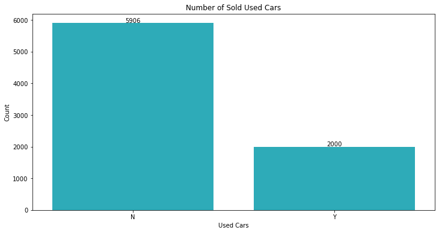

```python
# different classes in the sold column
sold_counts = cars_df.sold.value_counts()

# plot a bar plot and using text annotation the values on the bars
plt.figure(figsize=(12,6))

base_color = sb.color_palette()[9]
sb.barplot(sold_counts.index.values,sold_counts,color = base_color)
plt.title('Number of Sold Used Cars')
plt.xlabel('Used Cars')
plt.ylabel('Count')
base_color = sb.color_palette()[0]

# get the tick locations and labels
# logic to print the values on each bar
for i in range(sold_counts.shape[0]):
    count = sold_counts[i]
#print the values on top of the bars
    plt.text(i,count+170,count,ha ='center',va = 'top');
```

Obsevation

it indicates that 5906 cars are unsold and the number of sold cars (2000) is less than half the unsold cars.

### What is the frequency distribution of the car names

```python
# get the number of various car names
car_names = cars_df.name.value_counts()
```

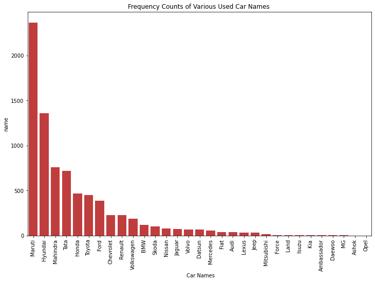

```python
# plotting the frequency distribution of car names
plt.figure(figsize = (12, 8))
base_color = sb.color_palette()[3]
plt.title('Frequency Counts of Various Used Car Names ')
plt.xlabel(' Car Names')
plt.ylabel('Count')
sb.barplot(car_names.index,car_names,color = base_color);
plt.xticks(rotation = 90);
```

Obsevation

it can be seen that the brand of cars that appears most is Maurti followed by Myundai, Mahindra and Tata. We will have to find out whether the are the highest selling cars

```python
# Define a function to visually determine the frequency counts of the various features.

y='Frequency Count'

def freq_count(x):
  # data setup
    plt.figure(figsize =(20,5))
    base_color = sb.color_palette()[0]
    sb.countplot(data = cars_df, x=x, color = base_color)

    plt.title('{} by {}' .format(x,y))
    plt.xlabel('{}'.format(x))
    plt.ylabel('{}'.format(y));
```

### Frequency distribution of seller type

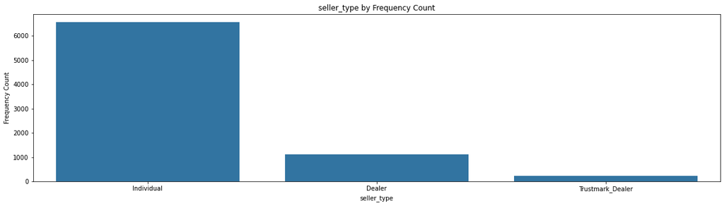

```python
# Plot frequency distribution of seller type
freq_count('seller_type')
```

### Frequency distribution for Owner in the Dataset

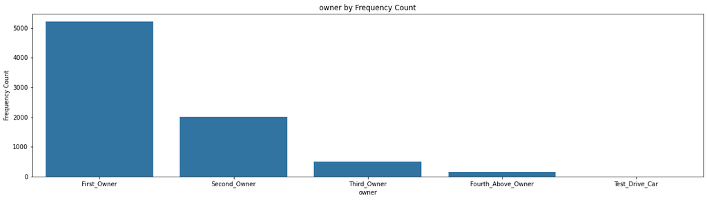

```python
# plot frequency distribution of owner
freq_count('owner')
```

Observation: Most for sale used cars are coming from the first owner.

### Frequency distribution for transmission in dataset

```python
# Get car transmission
car_trans = cars_df.transmission.value_counts()
car_trans
```

```
Manual       6865
Automatic    1041
Name: transmission, dtype: int64
```

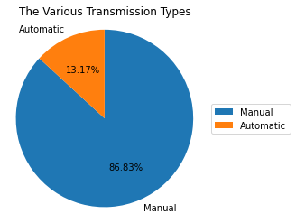

```python
#The axis function call and 'square' argument makes it so that the scaling of the plot is equal on both the x- and y-axes.
#Without this call, the pie could end up looking oval-shaped, rather than a circle.
label = cars_df.transmission.value_counts().index
plt.pie(car_trans,labels =label,startangle =90,autopct='%1.2f%%',counterclock =False)
title =plt.title('The Various Transmission Types')
title.set_ha('center')
plt.legend( bbox_to_anchor=(1,0.5), loc="center right", fontsize=10, bbox_transform=plt.gcf().transFigure)
plt.axis('square');
```

Observation: Automatic cars (13.17%) are way lesser than Manual cars (86.83%).

### Frequency distribution for mileage range in dataset

```python
# describe mileage
cars_df.mileage.describe()
```

```
count    7906.000000
mean       19.419861
std         4.036263
min         0.000000
25%        16.780000
50%        19.300000
75%        22.320000
max        42.000000
Name: mileage, dtype: float64
```

```python
# create range for mileage
cars_df.loc[(cars_df['mileage'] >= 0) & (cars_df['mileage'] <= 10), 'mileage'] = 1
cars_df.loc[(cars_df['mileage'] > 10) & (cars_df['mileage'] <= 20), 'mileage'] = 2
cars_df.loc[(cars_df['mileage'] > 20) & (cars_df['mileage'] <= 30), 'mileage'] = 3
cars_df.loc[(cars_df['mileage'] > 30), 'mileage'] = 4
cars_df.mileage.value_counts()
```

```
2.0    4447
3.0    3421
1.0      29
4.0       9
Name: mileage, dtype: int64
```

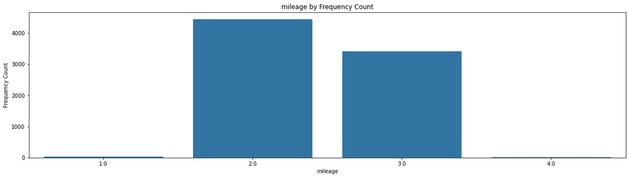

```python
# frequency count of mileage of cars
freq_count('mileage')
```

Observation: Most of the cars in the dataset have a mileage between 10 and 20 followed by 20 to 30.

### Frequency distribution for fuel

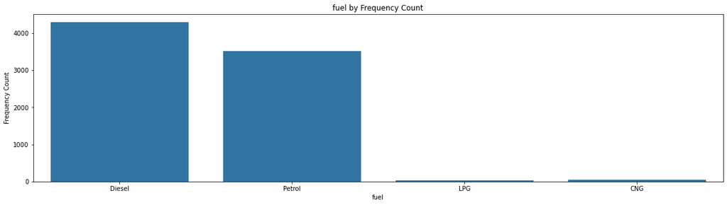

```python
# frequency count of fuel
freq_count('fuel')
```

Observation: Most of the cars run on Diesel followed by Petrol.

### Frequency distribution for region

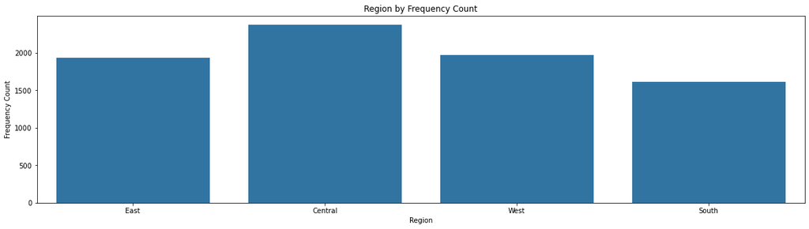

```python
# frequency count for region
freq_count('Region')
```

Observation: Majority of the cars are from Central

### Frequency distribution of selling price of cars

```
0    300000
dtype: int64
```

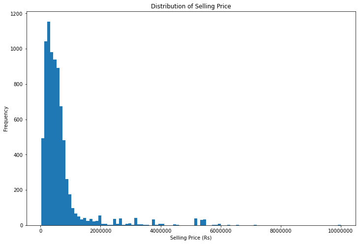

```python
# plot frequency distribution of selling price of cars
plt.figure(figsize=(12,8))
me = plt.gca()
me.ticklabel_format(useOffset=False, style='plain')
me =sb.distplot(cars_df.selling_price, kde = False, hist_kws = {'alpha' : 1},bins =100);
me.set_title("Distribution of Selling Price")
me.set_xlabel("Selling Price (Rs)");
me.set_ylabel('Frequency');

print(cars_df.selling_price.mode())
```

Obeservation: Most of the used cars have selling price less than 2000000(Rs). Cars selling at 300000(Rs) are more than others.

### Frequency distribution of engine

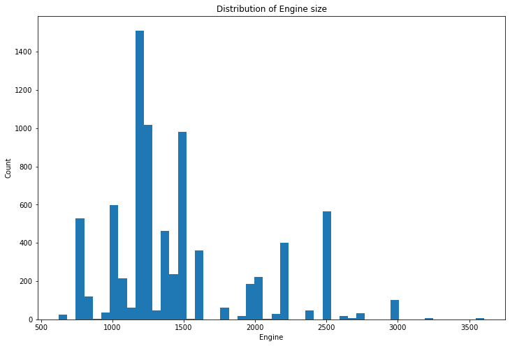

```python
# plot the frequency distribution of engine
plt.figure(figsize=(12,8))
me = plt.gca()
me.ticklabel_format(useOffset=False, style='plain')
sb.distplot(cars_df['engine'], kde = False, hist_kws = {'alpha' : 1},bins =50);
plt.title("Distribution of Engine size")
plt.xlabel("Engine");
plt.ylabel('Count');
```

Observation: Most of car engine range from 1000 to 1500.

### Frequency distribution of seats

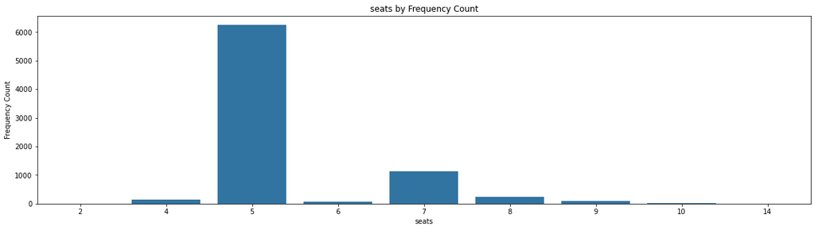

```python
# plot frequency distribution for seats
freq_count('seats')
```

Observation: Most of the cars are 5 seater followed by 7 seater.

### Insights from Univariate Exploration

1. The data contains 2000 sold cars and 5906 unsold cars.
2. Most of the used cars come from the central region.
3. The seller type for most of the cars is individual owners.
4. The descending order of the top three most appearing Car Brand name is Maurti, Hyundai and Mahindra.
5. Most of the cars run on Diesel followed by Petrol (Fuel types).
6. Most of the cars have a selling price between 0 and 2000000 (Rs). The selling price with most cars is 300000 (Rs).
7. Most of the used car engine are between 1000 and 1500.
8. Most of the cars have Manual transmission.
9. Most cars has mileage between 10 and 20.
10. Most of the cars are 5 seater cars.

The data contained no missing values nor duplicates so no cleaning was effected on it.

Due to the nature of the dataset I didn't clean and tidy data

## Bivariate Exploration

### 1. Relationship between Name and selling price

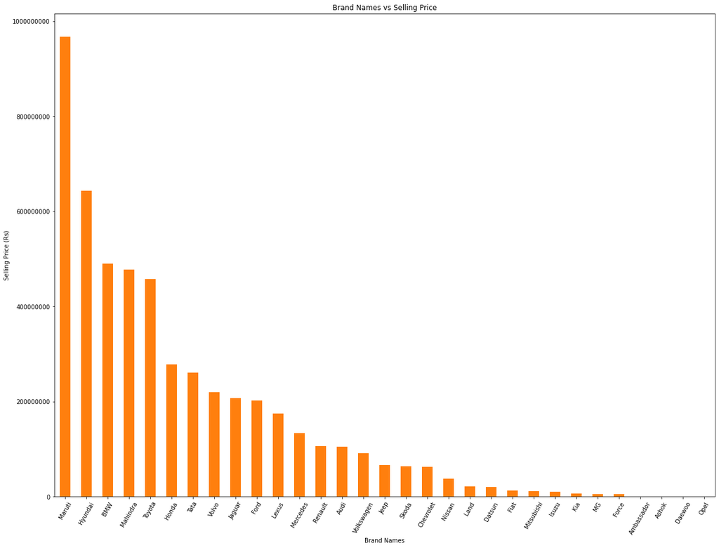

```python
#calculate sum of selling Price for each Brand name of used car
brand_name =cars_df.groupby('name').selling_price.sum().sort_values(ascending= False)

#calculate sum of selling Price for each Brand name of used car
plt.figure(figsize=(20,15))
#create bar plot with custom aesthetics
base_color = sb.color_palette()[1]
me = plt.gca()
me.ticklabel_format(useOffset=False, style='plain', axis='y')
brand_name.plot(kind='bar', title='Brand Names vs Selling Price',color = base_color,ylabel='Selling Price (Rs)', xlabel='Brand Names')

#rotate x-axis ticks vertically
plt.xticks(rotation=60);
```

Observation: Top three brand names with highest sum total of selling price of the cars are Maruti, Hyundai and BMW respectively. This means these brand names can be used to predict selling prices.

### Relationship between Name and sold

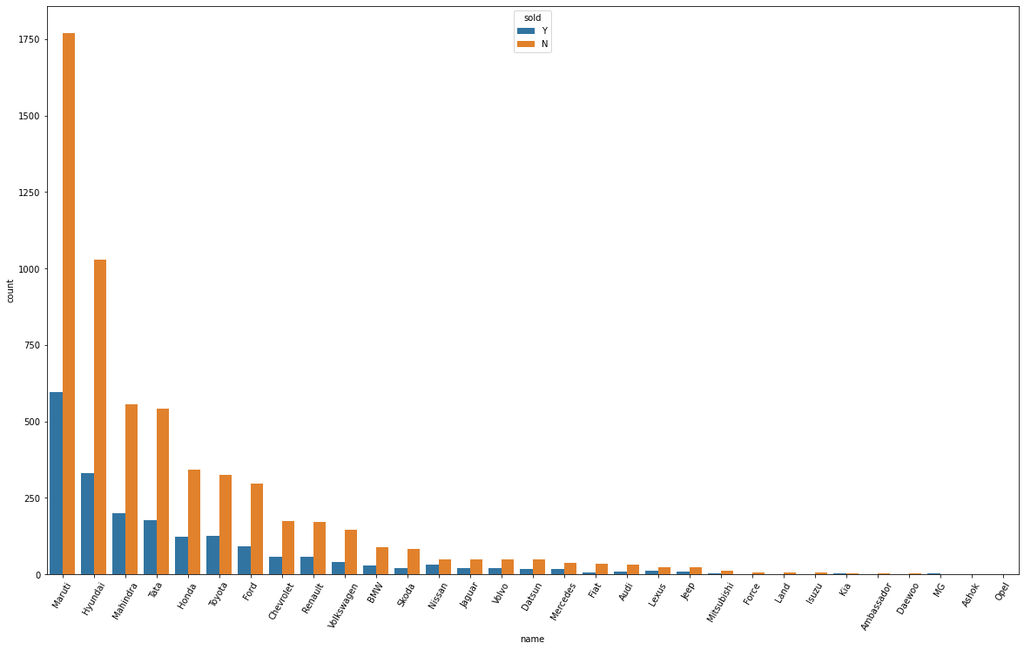

```python
# plot to display the relationship showing which brand names sold
plt.figure(figsize = [20,12])
sb.countplot(data = cars_df,x = 'name',hue ='sold',order =cars_df['name'].value_counts().index)
# rotate x-axis ticks vertically
plt.xticks(rotation=60);
```

Observation: The brand name with the highest number of sold cars also has the highest number of unsold cars. It is same for the second and third. The top three brand names in terms of sold and unsold number of cars are Maruti, Hyundai and Mahindra respectively.

### 2. Relationship between owner and selling price

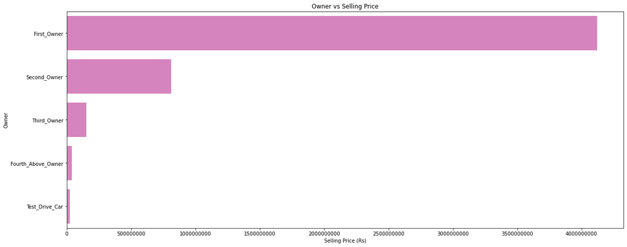

```python
# plot the relationship between the owner and the selling price
base_color=sb.color_palette()[6]
plt.figure(figsize = [20, 8])
me = plt.gca()
me.ticklabel_format(useOffset=False, style='plain')
car_owner = cars_df.groupby('owner').selling_price.sum().sort_values( ascending = False)
sb.barplot(car_owner,car_owner.index,color=base_color);
me.set_title('Owner vs Selling Price')
me.set_xlabel('Selling Price (Rs)')
me.set_ylabel('Owner');
```

Observation: First owner cars have the highest selling price followed by second owner and third.

### Relationship between owner and sold

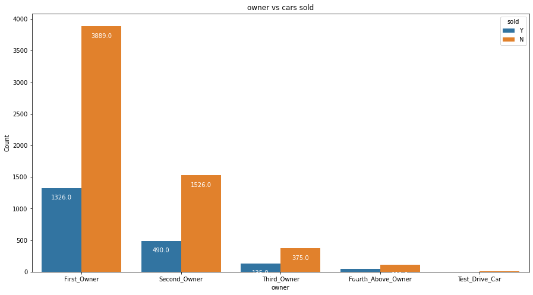

```python
# define a function to help in determining the relationship between a variable and sold.
def let_relate(var1):
    plt.figure(figsize = [15,8])
    me = sb.countplot(data = cars_df,x = var1,hue ='sold')
    me.set_title(f'{var1} vs cars sold')
    me.set_xlabel(var1)
    me.set_ylabel('Count')
    for p in me.patches:
        me.annotate(f'\n{p.get_height()}', (p.get_x()+0.2, p.get_height()), ha='center', va='top', color='white', size=10)
    plt.show()

# plot the relationship between owner and sold
let_relate('owner')
```

Observation: First owner cars are more than any of the remaining owner type cars. The most sold cars are from first owner followed by second owner.

### 3. Relationship between mileage and selling_price

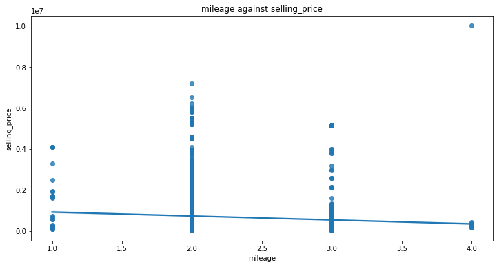

```python
# define a function to find the relationship between two variables
def relationship_btw(var1, var2):
    plt.figure(figsize=[12,6])
    sb.regplot(data=cars_df, x=var1, y=var2)
    plt.xlabel(var1)
    plt.ylabel(var2)
    plt.title(f'{var1} against {var2}')

# plot a scatter diagram with trend line.
relationship_btw('mileage','selling_price')
```

### Relationship between mileage and sold

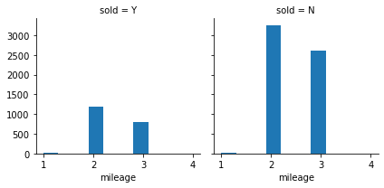

```python
# plot a histogram using  FacetGrid to compare sold and unsold distribution of mileage
fg = sb.FacetGrid(cars_df, col='sold');
fg.map(plt.hist, 'mileage');
```

Observation: Most of the sold and unsold cars fall between the mileage of 10 and 20.

### 4. Relationship between Transmission and sold

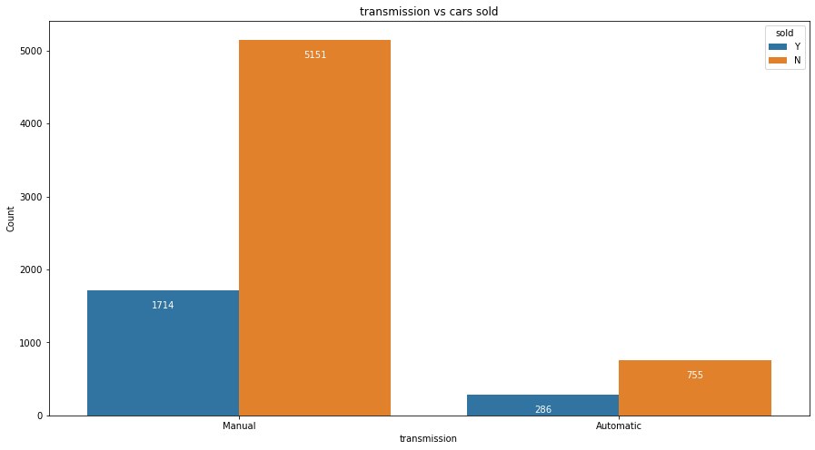

```python
# plot to display the relationship between transmission mode and sold
let_relate('transmission')
```

Observation: Manual transmission cars are often sold as compared to automatic. Manual also happen to the most in stock between the the two.

### Relationship between Transmission and selling price

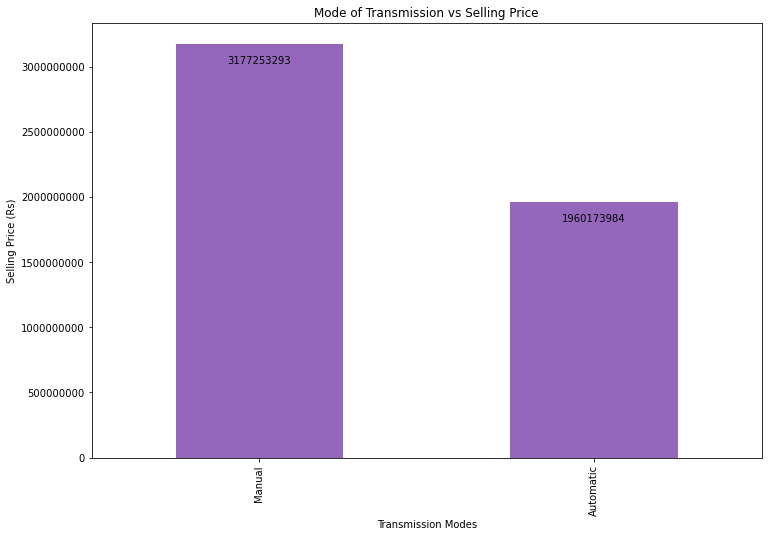

```python
# calculate sum of selling Price for each transmission mode of used car
car_trans = cars_df.groupby('transmission').selling_price.sum().sort_values(ascending = False)

# plot a plot to show the mode of transmission and the selling  price
plt.figure(figsize=(12,8))

# create bar plot
base_color = sb.color_palette()[4]
me = plt.gca()
me.ticklabel_format(useOffset=False, style='plain', axis='y')
car_trans.plot(kind='bar', title='Mode of Transmission vs Selling Price',color = base_color,
               ylabel='Selling Price (Rs)', xlabel='Transmission Modes');
for p in me.patches:
    me.annotate(f'\n{p.get_height()}', (p.get_x()+0.25, p.get_height()), ha='center', va='top', color='black', size=10)
plt.show()
```

Observation: Manual transmission cars have higher selling price than automatic transmission cars.

### 5. Relationship between engine and selling price

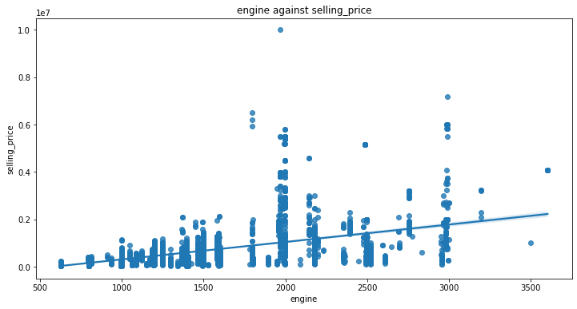

```python
# plot a scatter plot to show relationship
relationship_btw('engine','selling_price')
```

### Relationship between engine and sold

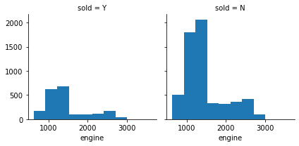

```python
# plot facet-grid
fg = sb.FacetGrid(cars_df, col='sold');
fg.map(plt.hist, 'engine');
```

Observation: Most of the sold cars have engine size between 1000 and 2000. It is the same for unsold cars.

### 6. Relationship between Fuel and sold

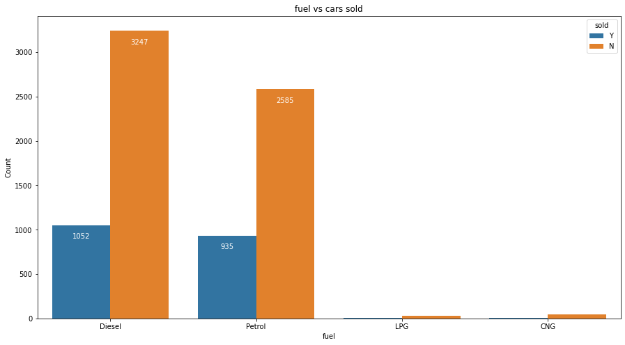

```python
# plot a count-plot to determine which fuel type are mostly sold
let_relate('fuel')
```

Observation: Out of the number of sold cars, Diesel using cars has the highest number. This is also true for unsold cars.

### Relationship between Fuel and selling price

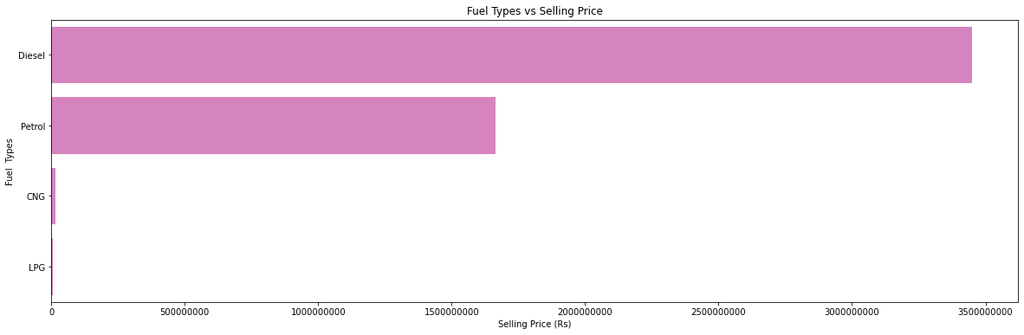

```python
# plot the relationship between the fuel types and the selling price
base_color=sb.color_palette()[6]
plt.figure(figsize = [20, 6])
me = plt.gca()
me.ticklabel_format(useOffset=False, style='plain')
car_fuel = cars_df.groupby('fuel').selling_price.sum().sort_values( ascending = False)
sb.barplot(car_fuel,car_fuel.index,color=base_color);
me.set_title('Fuel Types vs Selling Price')
me.set_xlabel('Selling Price (Rs)')
me.set_ylabel('Fuel  Types');
```

Observation: Diesel using cars have the highest selling price followed by Petrol using cars.

### 7. Relationship between Region and sold

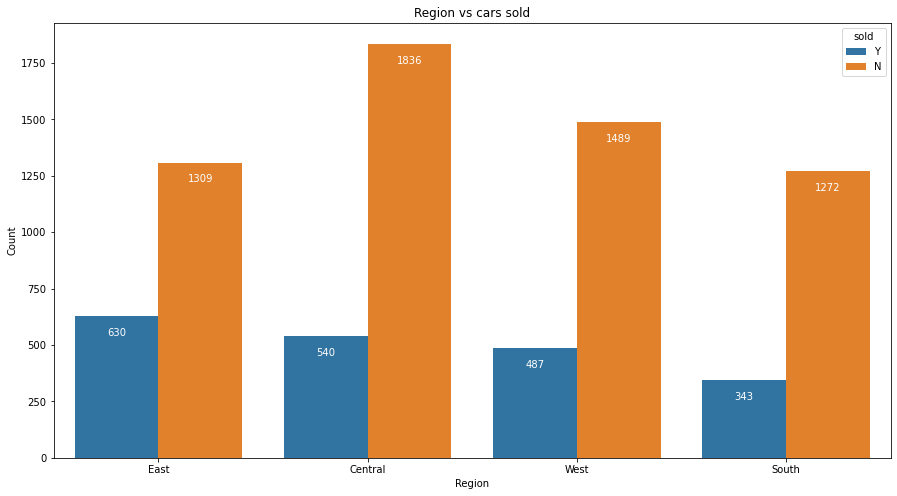

```python
# plot to find out which region had more more cars sold and unsold
let_relate('Region')
```

Observation: The region with the highest sold number of cars is the East, followed by Central, West and South respectively. The region with the highest unsold number of cars is Central followed by West, East and South respectively.

### Relationship between Region and selling price

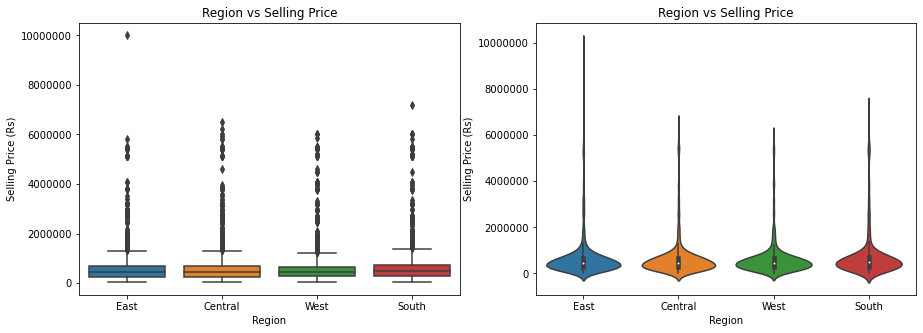

```python
# create a function to plot box and violin plot
def box_violin(slot1):
    plt.figure(figsize = [15,5])
    plt.subplot(1,2,1)
    me = plt.gca()
    me.ticklabel_format(useOffset=False, style='plain')
    sb.boxplot(data = cars_df,x = slot1,y = 'selling_price' );
    me.set_title(f'{slot1} vs Selling Price')
    me.set_xlabel(slot1)
    me.set_ylabel('Selling Price (Rs)')
    plt.subplot(1,2,2)
    me = plt.gca()
    me.ticklabel_format(useOffset=False, style='plain')
    sb.violinplot(data = cars_df,x = slot1,y = 'selling_price' );
    me.set_title(f'{slot1} vs Selling Price')
    me.set_xlabel(slot1)
    me.set_ylabel('Selling Price (Rs)');

# plot a box and violin plot for region and selling price to determine their relationship
box_violin('Region')
```

Observation: This explains the importance of the Regions (East, Central, West, and South) in estimating the price of a car. It demonstrates that the east region had the highest selling price for automobiles; in this area, we can see the existence of an outlier that raises the price to the greatest level. The south region, which also has an outlier, was next.

### 8. Relationship between Seats and sold

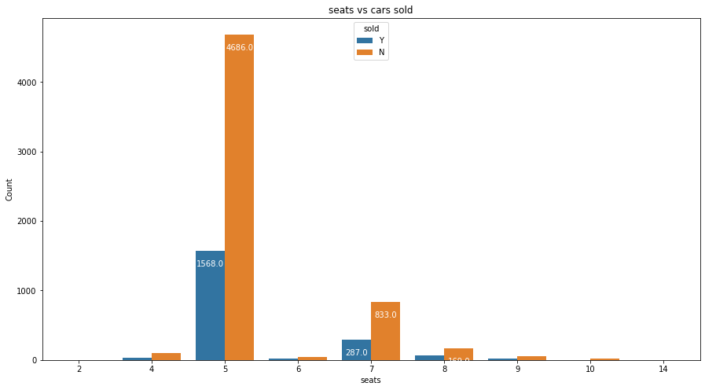

```python
# plot to find out which region had more more cars sold and unsold
let_relate('seats')
```

Observation: Cars with 5 seats are more than cars with any number of seats. 5 seater cars are mostly sold followed by 7 seater cars.

### Relationship between Seats and selling price

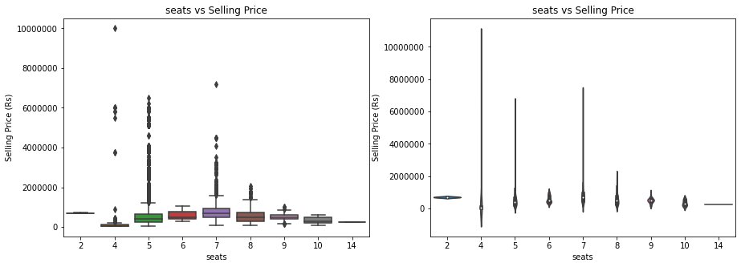

```python
# create box-plot and violin-plot to show the relationship of Seats and selling price
box_violin('seats')
```

Observation: Four seater cars have a highest selling price.

### Relationship between other features that are not our main feature of interest such as seller types and year

```python
# Group Years and encode them

cars_df.loc[(cars_df['year'] >= 1994) & (cars_df['year'] <= 1999), 'year'] = 1
cars_df.loc[(cars_df['year'] >= 2000) & (cars_df['year'] <= 2005), 'year'] = 2
cars_df.loc[(cars_df['year'] >= 2006) & (cars_df['year'] <= 2011), 'year'] = 3
cars_df.loc[(cars_df['year'] >= 2012) & (cars_df['year'] <= 2017), 'year'] = 4
cars_df.loc[cars_df['year']  >= 2018, 'year'] = 5

cars_df.head()
```

|  | Sales_ID | name | year | selling_price | km_driven | Region | State or Province | City | fuel | seller_type | transmission | owner | mileage | engine | max_power | torque | seats | sold |
| --- | --- | --- | --- | --- | --- | --- | --- | --- | --- | --- | --- | --- | --- | --- | --- | --- | --- | --- |
| 0 | 1 | Maruti | 4 | 450000 | 145500 | East | District of Columbia | Washington | Diesel | Individual | Manual | First_Owner | 3.0 | 1248 | 74.00 | 190Nm@ 2000rpm | 5 | Y |
| 1 | 2 | Skoda | 4 | 370000 | 120000 | East | New York | New York City | Diesel | Individual | Manual | Second_Owner | 3.0 | 1498 | 103.52 | 250Nm@ 1500-2500rpm | 5 | Y |
| 2 | 3 | Honda | 3 | 158000 | 140000 | Central | Illinois | Chicago | Petrol | Individual | Manual | Third_Owner | 2.0 | 1497 | 78.00 | 12.7@ 2,700(kgm@ rpm) | 5 | Y |
| 3 | 4 | Hyundai | 3 | 225000 | 127000 | Central | Illinois | Chicago | Diesel | Individual | Manual | First_Owner | 3.0 | 1396 | 90.00 | 22.4 kgm at 1750-2750rpm | 5 | Y |
| 4 | 5 | Maruti | 3 | 130000 | 120000 | East | New York | New York City | Petrol | Individual | Manual | First_Owner | 2.0 | 1298 | 88.20 | 11.5@ 4,500(kgm@ rpm) | 5 | Y |

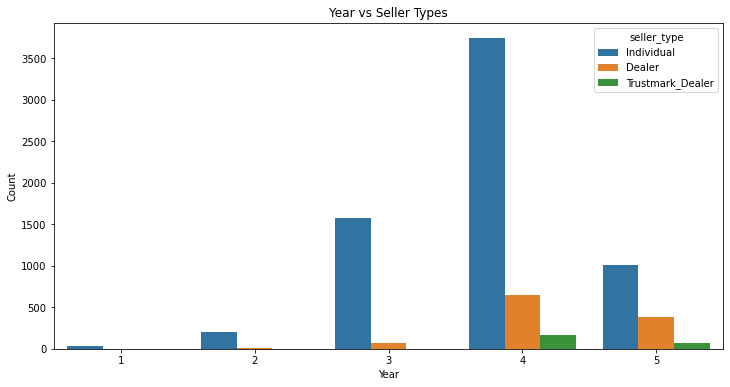

```python
#plot to show the relationship between seat and seller type
plt.figure(figsize =(12,6))
sb.countplot(data = cars_df, x = 'year', hue = 'seller_type')
plt.title('Year vs Seller Types')
plt.xlabel('Year')
plt.ylabel('Count');
```

Observation: Year group 4, (2012 - 2017) and 5, (2018+) have all seller types with individual seller type topping the chart for all five year groups.

## Multivariate Exploration

### Relationship between Name, Selling price and Sold

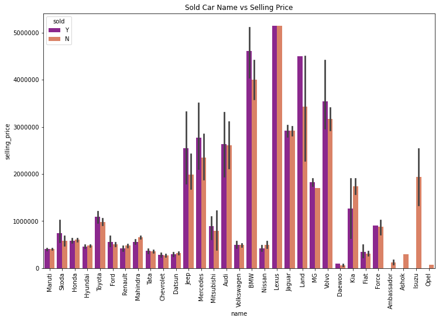

```python
plt.figure(figsize =(12,8))
me = plt.gca()
me.ticklabel_format(useOffset=False, style='plain')
me.set_title('Sold Car Name vs Selling Price')
me.set_ylabel('Selling Price')
me.set_xlabel('Car Names');
plt.xticks(rotation = 90)
sb.barplot(data = cars_df,x = 'name',y = 'selling_price',hue ='sold',palette = 'plasma');
```

Observation: Lexus turns out to have the highest selling price followed by BMW.

### Relationship between Year, Selling price and Sold

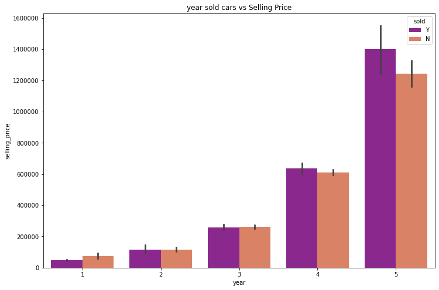

```python
# Define the function to determine multivariate relationship
def multi_plot(var1):
    plt.figure(figsize =(12,8))
    me = plt.gca()
    me.ticklabel_format(useOffset=False, style='plain')
    me.set_title(f'{var1} sold cars vs Selling Price')
    me.set_ylabel('Selling Price')
    me.set_xlabel('year');
    sb.barplot(data = cars_df,x = var1,y = 'selling_price',hue ='sold',palette = 'plasma');

# plot a graph to display how year and sold affects selling price
multi_plot('year')
```

Observation: In the 1990's (first year group) the selling price for unsold cars exceeded that of sold cars. Also, this graph indicates that selling price increases with time (years).

### Relationship between Region, Selling price and Sold

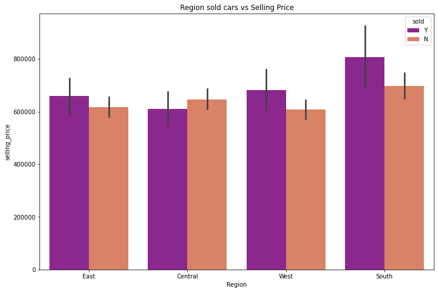

```python
# plot for region and selling price
multi_plot('Region')
```

Observation: Selling price is high in the south region followed by the west.

### Relationship between Transmission, year and selling price

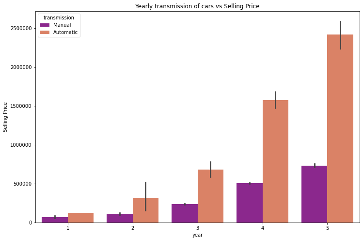

```python
plt.figure(figsize =(12,8))
me = plt.gca()
me.ticklabel_format(useOffset=False, style='plain')
me.set_title('Yearly transmission of cars vs Selling Price')
sb.barplot(data = cars_df,x = 'year',y = 'selling_price',hue ='transmission',palette = 'plasma');
me.set_ylabel('Selling Price')
me.set_xlabel('year');
```

Observation: In general, automatic cars have higher selling price than manual cars.

### Multivariate Exploration Insight

1. Lexus turns out to have the highest selling price followed by BMW.
2. In the 1990's (first year group), the selling price for unsold cars exceeded that of sold cars. Also, it was observed that selling price increases with time (years).
3. South region has the highest selling price for used cars.
4. Automatic cars have higher selling price than manual cars

## Conclusions

1. Among many features it was observed that Region, Name and Year are categories which affect buying and selling of car. Fuel feature does not affect buying and selling of car.
2. Cars with high selling price are sold less compared to cars with low selling price. This is observed when Maruti, Hyundai which is the most sold car turned out to have a way lower selling price as compared to Lexus and BMW which had high selling price but are sold less.
3. The number of seats in a car doesn't affect the selling price of a car.
4. Selling price for both Manual and Automatic cars increase with time (years). Automatic is selling exponentially higher than Manual cars in year group 4 and 5.